# Risk Factor Analysis

## Outcome Variable

**Outcome Variable:** stunted

## Predictor Variables

**Intervention Variable:** perdiar6

**Adjustment Set:**

- arm
- sex
- W_mage
- meducyrs
- feducyrs
- hhwealth_quart
- hfoodsec
- W_mhtcm
- W_mwtkg
- W_mbmi
- W_birthwt
- W_birthlen
- W_nrooms
- month
- brthmon
- impfloor
- impsan
- safeh20
- delta_W_mage
- delta_meducyrs
- delta_feducyrs
- delta_hhwealth_quart
- delta_hfoodsec
- delta_W_mhtcm
- delta_W_mwtkg
- delta_W_mbmi
- delta_W_birthwt
- delta_W_birthlen
- delta_W_nrooms
- delta_month
- delta_brthmon
- delta_impfloor
- delta_impsan
- delta_safeh20

## Stratifying Variables

The analysis was stratified on these variable(s):

- agecat
- studyid
- country

## Data Summary

| agecat | studyid | country | perdiar6 | stunted | n_cell | n |
| --- | --- | --- | --- | --- | --- | --- |
| Birth | ki0047075b-MAL-ED | BANGLADESH | 0% | 0 | 58 | 231 |
| Birth | ki0047075b-MAL-ED | BANGLADESH | 0% | 1 | 14 | 231 |
| Birth | ki0047075b-MAL-ED | BANGLADESH | (0%, 5%] | 0 | 78 | 231 |
| Birth | ki0047075b-MAL-ED | BANGLADESH | (0%, 5%] | 1 | 12 | 231 |
| Birth | ki0047075b-MAL-ED | BANGLADESH | >5% | 0 | 51 | 231 |
| Birth | ki0047075b-MAL-ED | BANGLADESH | >5% | 1 | 18 | 231 |
| Birth | ki0047075b-MAL-ED | BRAZIL | 0% | 0 | 48 | 65 |
| Birth | ki0047075b-MAL-ED | BRAZIL | 0% | 1 | 9 | 65 |
| Birth | ki0047075b-MAL-ED | BRAZIL | (0%, 5%] | 0 | 6 | 65 |
| Birth | ki0047075b-MAL-ED | BRAZIL | (0%, 5%] | 1 | 0 | 65 |
| Birth | ki0047075b-MAL-ED | BRAZIL | >5% | 0 | 2 | 65 |
| Birth | ki0047075b-MAL-ED | BRAZIL | >5% | 1 | 0 | 65 |
| Birth | ki0047075b-MAL-ED | INDIA | 0% | 0 | 10 | 47 |
| Birth | ki0047075b-MAL-ED | INDIA | 0% | 1 | 2 | 47 |
| Birth | ki0047075b-MAL-ED | INDIA | (0%, 5%] | 0 | 19 | 47 |
| Birth | ki0047075b-MAL-ED | INDIA | (0%, 5%] | 1 | 5 | 47 |
| Birth | ki0047075b-MAL-ED | INDIA | >5% | 0 | 8 | 47 |
| Birth | ki0047075b-MAL-ED | INDIA | >5% | 1 | 3 | 47 |
| Birth | ki0047075b-MAL-ED | NEPAL | 0% | 0 | 8 | 27 |
| Birth | ki0047075b-MAL-ED | NEPAL | 0% | 1 | 0 | 27 |
| Birth | ki0047075b-MAL-ED | NEPAL | (0%, 5%] | 0 | 10 | 27 |
| Birth | ki0047075b-MAL-ED | NEPAL | (0%, 5%] | 1 | 0 | 27 |
| Birth | ki0047075b-MAL-ED | NEPAL | >5% | 0 | 7 | 27 |
| Birth | ki0047075b-MAL-ED | NEPAL | >5% | 1 | 2 | 27 |
| Birth | ki0047075b-MAL-ED | PERU | 0% | 0 | 58 | 233 |
| Birth | ki0047075b-MAL-ED | PERU | 0% | 1 | 9 | 233 |
| Birth | ki0047075b-MAL-ED | PERU | (0%, 5%] | 0 | 64 | 233 |
| Birth | ki0047075b-MAL-ED | PERU | (0%, 5%] | 1 | 8 | 233 |
| Birth | ki0047075b-MAL-ED | PERU | >5% | 0 | 85 | 233 |
| Birth | ki0047075b-MAL-ED | PERU | >5% | 1 | 9 | 233 |

[output cut: 204 more lines]

The following strata were considered:

- agecat: 24 months, studyid: ki0047075b-MAL-ED, country: BANGLADESH
- agecat: 24 months, studyid: ki0047075b-MAL-ED, country: BRAZIL
- agecat: 24 months, studyid: ki0047075b-MAL-ED, country: INDIA
- agecat: 24 months, studyid: ki0047075b-MAL-ED, country: NEPAL
- agecat: 24 months, studyid: ki0047075b-MAL-ED, country: PERU
- agecat: 24 months, studyid: ki0047075b-MAL-ED, country: SOUTH AFRICA
- agecat: 24 months, studyid: ki0047075b-MAL-ED, country: TANZANIA, UNITED REPUBLIC OF
- agecat: 24 months, studyid: ki1000109-EE, country: PAKISTAN
- agecat: 24 months, studyid: ki1017093-NIH-Birth, country: BANGLADESH
- agecat: 24 months, studyid: ki1017093b-PROVIDE, country: BANGLADESH
- agecat: 24 months, studyid: ki1017093c-NIH-Crypto, country: BANGLADESH
- agecat: 24 months, studyid: ki1114097-CMIN, country: BANGLADESH
- agecat: 24 months, studyid: ki1114097-CONTENT, country: PERU
- agecat: 6 months, studyid: ki0047075b-MAL-ED, country: BANGLADESH
- agecat: 6 months, studyid: ki0047075b-MAL-ED, country: BRAZIL
- agecat: 6 months, studyid: ki0047075b-MAL-ED, country: INDIA
- agecat: 6 months, studyid: ki0047075b-MAL-ED, country: NEPAL
- agecat: 6 months, studyid: ki0047075b-MAL-ED, country: PERU
- agecat: 6 months, studyid: ki0047075b-MAL-ED, country: SOUTH AFRICA
- agecat: 6 months, studyid: ki0047075b-MAL-ED, country: TANZANIA, UNITED REPUBLIC OF
- agecat: 6 months, studyid: ki1000109-EE, country: PAKISTAN
- agecat: 6 months, studyid: ki1017093-NIH-Birth, country: BANGLADESH
- agecat: 6 months, studyid: ki1017093b-PROVIDE, country: BANGLADESH
- agecat: 6 months, studyid: ki1017093c-NIH-Crypto, country: BANGLADESH
- agecat: 6 months, studyid: ki1114097-CMIN, country: BANGLADESH
- agecat: 6 months, studyid: ki1114097-CONTENT, country: PERU
- agecat: Birth, studyid: ki0047075b-MAL-ED, country: BANGLADESH
- agecat: Birth, studyid: ki0047075b-MAL-ED, country: BRAZIL
- agecat: Birth, studyid: ki0047075b-MAL-ED, country: INDIA
- agecat: Birth, studyid: ki0047075b-MAL-ED, country: NEPAL
- agecat: Birth, studyid: ki0047075b-MAL-ED, country: PERU
- agecat: Birth, studyid: ki0047075b-MAL-ED, country: SOUTH AFRICA
- agecat: Birth, studyid: ki0047075b-MAL-ED, country: TANZANIA, UNITED REPUBLIC OF
- agecat: Birth, studyid: ki1000109-EE, country: PAKISTAN
- agecat: Birth, studyid: ki1017093-NIH-Birth, country: BANGLADESH
- agecat: Birth, studyid: ki1017093b-PROVIDE, country: BANGLADESH
- agecat: Birth, studyid: ki1017093c-NIH-Crypto, country: BANGLADESH
- agecat: Birth, studyid: ki1114097-CMIN, country: BANGLADESH
- agecat: Birth, studyid: ki1114097-CONTENT, country: PERU

### Dropped Strata

Some strata were dropped due to rare outcomes:

- agecat: Birth, studyid: ki0047075b-MAL-ED, country: BRAZIL
- agecat: Birth, studyid: ki0047075b-MAL-ED, country: INDIA
- agecat: Birth, studyid: ki0047075b-MAL-ED, country: NEPAL
- agecat: Birth, studyid: ki0047075b-MAL-ED, country: SOUTH AFRICA
- agecat: Birth, studyid: ki0047075b-MAL-ED, country: TANZANIA, UNITED REPUBLIC OF
- agecat: Birth, studyid: ki1000109-EE, country: PAKISTAN
- agecat: Birth, studyid: ki1114097-CMIN, country: BANGLADESH
- agecat: Birth, studyid: ki1114097-CONTENT, country: PERU
- agecat: 6 months, studyid: ki0047075b-MAL-ED, country: BRAZIL
- agecat: 6 months, studyid: ki0047075b-MAL-ED, country: NEPAL
- agecat: 6 months, studyid: ki0047075b-MAL-ED, country: SOUTH AFRICA
- agecat: 6 months, studyid: ki1000109-EE, country: PAKISTAN
- agecat: 6 months, studyid: ki1114097-CONTENT, country: PERU
- agecat: 24 months, studyid: ki0047075b-MAL-ED, country: BRAZIL
- agecat: 24 months, studyid: ki0047075b-MAL-ED, country: SOUTH AFRICA
- agecat: 24 months, studyid: ki1000109-EE, country: PAKISTAN
- agecat: 24 months, studyid: ki1114097-CONTENT, country: PERU

## Methods Detail

We’re interested in the causal parameters $E[Y_a]$ for all values of $a \in \mathcal{A}$. These parameters represent the mean outcome if, possibly contrary to fact, we intervened to set all units to have $A=a$. Under the randomization and positivity assumptions, these are identified by the statistical parameters $\psi_a=E_W[E_{Y|A,W}(Y|A=a,W)]$. In addition, we’re interested in the mean of $Y$, $E[Y]$ under no intervention (the observed mean). We will estimate these parameters by using SuperLearner to fit the relevant likelihood factors – $E_{Y|A,W}(Y|A=a,W)$ and $p(A=a|W)$, and then updating our likelihood fit using a joint TMLE.

For unadjusted analyses ($W=\{\}$), initial likelihoods were estimated using Lrnr_glm to estimate the simple $E(Y|A)$ and Lrnr_mean to estimate $p(A)$. For adjusted analyses, a small library containing Lrnr_glmnet, Lrnr_xgboost, and Lrnr_mean was used.

Having estimated these parameters, we will then use the delta method to estimate relative risks and attributable risks relative to a prespecified baseline level of $A$.

# Results Detail

## Results Plots

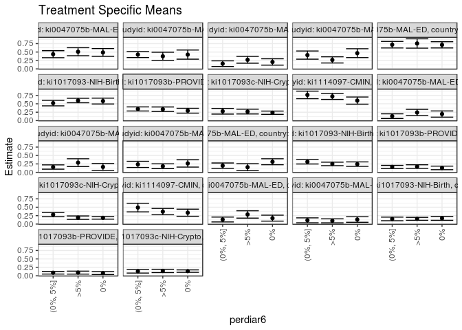

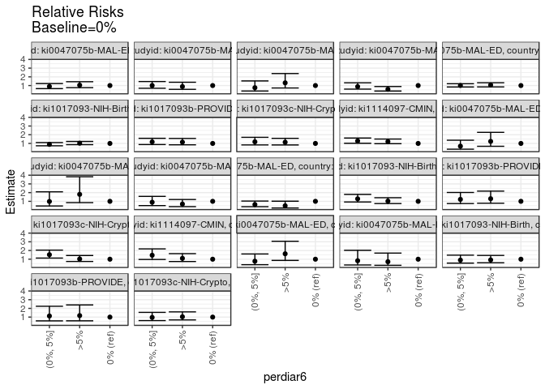

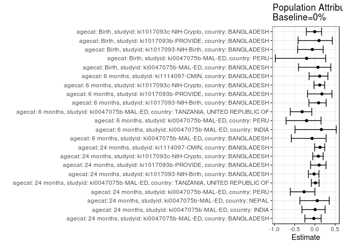

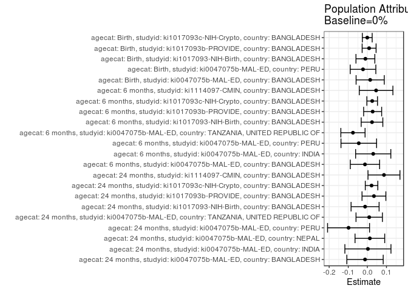

## Results Table

### Parameter: TSM

| agecat | studyid | country | intervention_level | baseline_level | estimate | ci_lower | ci_upper |
| --- | --- | --- | --- | --- | --- | --- | --- |
| Birth | ki0047075b-MAL-ED | BANGLADESH | 0% | NA | 0.1756824 | 0.0869720 | 0.2643929 |
| Birth | ki0047075b-MAL-ED | BANGLADESH | (0%, 5%] | NA | 0.1353087 | 0.0630765 | 0.2075408 |
| Birth | ki0047075b-MAL-ED | BANGLADESH | >5% | NA | 0.2852627 | 0.1761887 | 0.3943367 |
| Birth | ki0047075b-MAL-ED | PERU | 0% | NA | 0.1343284 | 0.0524998 | 0.2161570 |
| Birth | ki0047075b-MAL-ED | PERU | (0%, 5%] | NA | 0.1111111 | 0.0383636 | 0.1838586 |
| Birth | ki0047075b-MAL-ED | PERU | >5% | NA | 0.0957447 | 0.0361344 | 0.1553549 |
| Birth | ki1017093-NIH-Birth | BANGLADESH | 0% | NA | 0.1689374 | 0.1108832 | 0.2269916 |
| Birth | ki1017093-NIH-Birth | BANGLADESH | (0%, 5%] | NA | 0.1518792 | 0.0985490 | 0.2052095 |
| Birth | ki1017093-NIH-Birth | BANGLADESH | >5% | NA | 0.1555027 | 0.1116774 | 0.1993280 |
| Birth | ki1017093b-PROVIDE | BANGLADESH | 0% | NA | 0.0798837 | 0.0371624 | 0.1226049 |
| Birth | ki1017093b-PROVIDE | BANGLADESH | (0%, 5%] | NA | 0.0900942 | 0.0510363 | 0.1291522 |
| Birth | ki1017093b-PROVIDE | BANGLADESH | >5% | NA | 0.0936710 | 0.0492725 | 0.1380694 |
| Birth | ki1017093c-NIH-Crypto | BANGLADESH | 0% | NA | 0.1384923 | 0.1023642 | 0.1746203 |
| Birth | ki1017093c-NIH-Crypto | BANGLADESH | (0%, 5%] | NA | 0.1332158 | 0.0805773 | 0.1858544 |
| Birth | ki1017093c-NIH-Crypto | BANGLADESH | >5% | NA | 0.1439363 | 0.0945667 | 0.1933058 |
| 6 months | ki0047075b-MAL-ED | BANGLADESH | 0% | NA | 0.1951476 | 0.1027105 | 0.2875846 |
| 6 months | ki0047075b-MAL-ED | BANGLADESH | (0%, 5%] | NA | 0.1330605 | 0.0643205 | 0.2018004 |
| 6 months | ki0047075b-MAL-ED | BANGLADESH | >5% | NA | 0.2411680 | 0.1467662 | 0.3355699 |
| 6 months | ki0047075b-MAL-ED | INDIA | 0% | NA | 0.1600000 | 0.0581679 | 0.2618321 |
| 6 months | ki0047075b-MAL-ED | INDIA | (0%, 5%] | NA | 0.1574803 | 0.0939953 | 0.2209654 |
| 6 months | ki0047075b-MAL-ED | INDIA | >5% | NA | 0.2881356 | 0.1723269 | 0.4039443 |
| 6 months | ki0047075b-MAL-ED | PERU | 0% | NA | 0.2646983 | 0.1561977 | 0.3731988 |
| 6 months | ki0047075b-MAL-ED | PERU | (0%, 5%] | NA | 0.2367636 | 0.1453444 | 0.3281827 |
| 6 months | ki0047075b-MAL-ED | PERU | >5% | NA | 0.1812386 | 0.1100894 | 0.2523878 |
| 6 months | ki0047075b-MAL-ED | TANZANIA, UNITED REPUBLIC OF | 0% | NA | 0.3142857 | 0.2253107 | 0.4032608 |
| 6 months | ki0047075b-MAL-ED | TANZANIA, UNITED REPUBLIC OF | (0%, 5%] | NA | 0.1979167 | 0.1180539 | 0.2777794 |
| 6 months | ki0047075b-MAL-ED | TANZANIA, UNITED REPUBLIC OF | >5% | NA | 0.1521739 | 0.0481643 | 0.2561836 |
| 6 months | ki1017093-NIH-Birth | BANGLADESH | 0% | NA | 0.2437975 | 0.1775720 | 0.3100231 |
| 6 months | ki1017093-NIH-Birth | BANGLADESH | (0%, 5%] | NA | 0.3141679 | 0.2478600 | 0.3804758 |
| 6 months | ki1017093-NIH-Birth | BANGLADESH | >5% | NA | 0.2500583 | 0.1983614 | 0.3017553 |
| 6 months | ki1017093b-PROVIDE | BANGLADESH | 0% | NA | 0.1312554 | 0.0779137 | 0.1845971 |
| 6 months | ki1017093b-PROVIDE | BANGLADESH | (0%, 5%] | NA | 0.1606977 | 0.1142348 | 0.2071605 |
| 6 months | ki1017093b-PROVIDE | BANGLADESH | >5% | NA | 0.1708140 | 0.1175386 | 0.2240894 |
| 6 months | ki1017093c-NIH-Crypto | BANGLADESH | 0% | NA | 0.1845269 | 0.1456298 | 0.2234240 |
| 6 months | ki1017093c-NIH-Crypto | BANGLADESH | (0%, 5%] | NA | 0.2803481 | 0.2171272 | 0.3435690 |
| 6 months | ki1017093c-NIH-Crypto | BANGLADESH | >5% | NA | 0.1896375 | 0.1387707 | 0.2405043 |
| 6 months | ki1114097-CMIN | BANGLADESH | 0% | NA | 0.3369352 | 0.2316537 | 0.4422167 |
| 6 months | ki1114097-CMIN | BANGLADESH | (0%, 5%] | NA | 0.4902857 | 0.3624985 | 0.6180728 |
| 6 months | ki1114097-CMIN | BANGLADESH | >5% | NA | 0.3701496 | 0.2765088 | 0.4637904 |
| 24 months | ki0047075b-MAL-ED | BANGLADESH | 0% | NA | 0.4886397 | 0.3731436 | 0.6041357 |
| 24 months | ki0047075b-MAL-ED | BANGLADESH | (0%, 5%] | NA | 0.4365189 | 0.3323629 | 0.5406750 |
| 24 months | ki0047075b-MAL-ED | BANGLADESH | >5% | NA | 0.5099133 | 0.3909184 | 0.6289083 |
| 24 months | ki0047075b-MAL-ED | INDIA | 0% | NA | 0.4244047 | 0.2886362 | 0.5601732 |
| 24 months | ki0047075b-MAL-ED | INDIA | (0%, 5%] | NA | 0.4254038 | 0.3372858 | 0.5135219 |
| 24 months | ki0047075b-MAL-ED | INDIA | >5% | NA | 0.3750221 | 0.2554176 | 0.4946265 |
| 24 months | ki0047075b-MAL-ED | NEPAL | 0% | NA | 0.2061714 | 0.1112324 | 0.3011104 |
| 24 months | ki0047075b-MAL-ED | NEPAL | (0%, 5%] | NA | 0.1552570 | 0.0716523 | 0.2388616 |
| 24 months | ki0047075b-MAL-ED | NEPAL | >5% | NA | 0.2701092 | 0.1688072 | 0.3714112 |
| 24 months | ki0047075b-MAL-ED | PERU | 0% | NA | 0.4666897 | 0.3354382 | 0.5979412 |
| 24 months | ki0047075b-MAL-ED | PERU | (0%, 5%] | NA | 0.4103782 | 0.2888406 | 0.5319157 |
| 24 months | ki0047075b-MAL-ED | PERU | >5% | NA | 0.2668948 | 0.1748026 | 0.3589869 |
| 24 months | ki0047075b-MAL-ED | TANZANIA, UNITED REPUBLIC OF | 0% | NA | 0.7145437 | 0.6224236 | 0.8066637 |
| 24 months | ki0047075b-MAL-ED | TANZANIA, UNITED REPUBLIC OF | (0%, 5%] | NA | 0.7189654 | 0.6214351 | 0.8164958 |
| 24 months | ki0047075b-MAL-ED | TANZANIA, UNITED REPUBLIC OF | >5% | NA | 0.7554508 | 0.6164708 | 0.8944307 |
| 24 months | ki1017093-NIH-Birth | BANGLADESH | 0% | NA | 0.5806723 | 0.4937518 | 0.6675928 |
| 24 months | ki1017093-NIH-Birth | BANGLADESH | (0%, 5%] | NA | 0.5198755 | 0.4384263 | 0.6013246 |
| 24 months | ki1017093-NIH-Birth | BANGLADESH | >5% | NA | 0.5964388 | 0.5301080 | 0.6627696 |
| 24 months | ki1017093b-PROVIDE | BANGLADESH | 0% | NA | 0.2942294 | 0.2220613 | 0.3663976 |
| 24 months | ki1017093b-PROVIDE | BANGLADESH | (0%, 5%] | NA | 0.3462314 | 0.2856206 | 0.4068422 |
| 24 months | ki1017093b-PROVIDE | BANGLADESH | >5% | NA | 0.3381236 | 0.2712152 | 0.4050321 |
| 24 months | ki1017093c-NIH-Crypto | BANGLADESH | 0% | NA | 0.2348381 | 0.1860311 | 0.2836451 |
| 24 months | ki1017093c-NIH-Crypto | BANGLADESH | (0%, 5%] | NA | 0.2785897 | 0.1942081 | 0.3629714 |
| 24 months | ki1017093c-NIH-Crypto | BANGLADESH | >5% | NA | 0.2684072 | 0.1974396 | 0.3393747 |
| 24 months | ki1114097-CMIN | BANGLADESH | 0% | NA | 0.5948132 | 0.4881723 | 0.7014541 |
| 24 months | ki1114097-CMIN | BANGLADESH | (0%, 5%] | NA | 0.7632831 | 0.6511052 | 0.8754611 |
| 24 months | ki1114097-CMIN | BANGLADESH | >5% | NA | 0.7193241 | 0.6295428 | 0.8091054 |

### Parameter: E(Y)

| agecat | studyid | country | intervention_level | baseline_level | estimate | ci_lower | ci_upper |
| --- | --- | --- | --- | --- | --- | --- | --- |
| Birth | ki0047075b-MAL-ED | BANGLADESH | NA | NA | 0.1904762 | 0.1397281 | 0.2412242 |
| Birth | ki0047075b-MAL-ED | PERU | NA | NA | 0.1115880 | 0.0710726 | 0.1521034 |
| Birth | ki1017093-NIH-Birth | BANGLADESH | NA | NA | 0.1586777 | 0.1295391 | 0.1878163 |
| Birth | ki1017093b-PROVIDE | BANGLADESH | NA | NA | 0.0890538 | 0.0649864 | 0.1131212 |
| Birth | ki1017093c-NIH-Crypto | BANGLADESH | NA | NA | 0.1379781 | 0.1129774 | 0.1629789 |
| 6 months | ki0047075b-MAL-ED | BANGLADESH | NA | NA | 0.1825726 | 0.1336978 | 0.2314474 |
| 6 months | ki0047075b-MAL-ED | INDIA | NA | NA | 0.1906780 | 0.1404524 | 0.2409036 |
| 6 months | ki0047075b-MAL-ED | PERU | NA | NA | 0.2197802 | 0.1705687 | 0.2689917 |
| 6 months | ki0047075b-MAL-ED | TANZANIA, UNITED REPUBLIC OF | NA | NA | 0.2388664 | 0.1855834 | 0.2921494 |
| 6 months | ki1017093-NIH-Birth | BANGLADESH | NA | NA | 0.2681564 | 0.2306532 | 0.3056597 |
| 6 months | ki1017093b-PROVIDE | BANGLADESH | NA | NA | 0.1589404 | 0.1297581 | 0.1881227 |
| 6 months | ki1017093c-NIH-Crypto | BANGLADESH | NA | NA | 0.2097902 | 0.1799252 | 0.2396552 |
| 6 months | ki1114097-CMIN | BANGLADESH | NA | NA | 0.3827160 | 0.3214780 | 0.4439541 |
| 24 months | ki0047075b-MAL-ED | BANGLADESH | NA | NA | 0.4764151 | 0.4090254 | 0.5438047 |
| 24 months | ki0047075b-MAL-ED | INDIA | NA | NA | 0.4273128 | 0.3628178 | 0.4918077 |
| 24 months | ki0047075b-MAL-ED | NEPAL | NA | NA | 0.2192982 | 0.1654718 | 0.2731246 |
| 24 months | ki0047075b-MAL-ED | PERU | NA | NA | 0.3681592 | 0.3013164 | 0.4350020 |
| 24 months | ki0047075b-MAL-ED | TANZANIA, UNITED REPUBLIC OF | NA | NA | 0.7242991 | 0.6642873 | 0.7843108 |
| 24 months | ki1017093-NIH-Birth | BANGLADESH | NA | NA | 0.5687646 | 0.5218455 | 0.6156837 |
| 24 months | ki1017093b-PROVIDE | BANGLADESH | NA | NA | 0.3287197 | 0.2903909 | 0.3670485 |
| 24 months | ki1017093c-NIH-Crypto | BANGLADESH | NA | NA | 0.2568093 | 0.2190047 | 0.2946140 |
| 24 months | ki1114097-CMIN | BANGLADESH | NA | NA | 0.6818182 | 0.6230135 | 0.7406228 |

### Parameter: RR

| agecat | studyid | country | intervention_level | baseline_level | estimate | ci_lower | ci_upper |
| --- | --- | --- | --- | --- | --- | --- | --- |
| Birth | ki0047075b-MAL-ED | BANGLADESH | 0% | 0% | 1.0000000 | 1.0000000 | 1.0000000 |
| Birth | ki0047075b-MAL-ED | BANGLADESH | (0%, 5%] | 0% | 0.7701890 | 0.3695480 | 1.6051800 |
| Birth | ki0047075b-MAL-ED | BANGLADESH | >5% | 0% | 1.6237405 | 0.8614272 | 3.0606570 |
| Birth | ki0047075b-MAL-ED | PERU | 0% | 0% | 1.0000000 | 1.0000000 | 1.0000000 |
| Birth | ki0047075b-MAL-ED | PERU | (0%, 5%] | 0% | 0.8271605 | 0.3382241 | 2.0229029 |
| Birth | ki0047075b-MAL-ED | PERU | >5% | 0% | 0.7127660 | 0.2983038 | 1.7030804 |
| Birth | ki1017093-NIH-Birth | BANGLADESH | 0% | 0% | 1.0000000 | 1.0000000 | 1.0000000 |
| Birth | ki1017093-NIH-Birth | BANGLADESH | (0%, 5%] | 0% | 0.8990266 | 0.5507391 | 1.4675713 |
| Birth | ki1017093-NIH-Birth | BANGLADESH | >5% | 0% | 0.9204754 | 0.5902135 | 1.4355399 |
| Birth | ki1017093b-PROVIDE | BANGLADESH | 0% | 0% | 1.0000000 | 1.0000000 | 1.0000000 |
| Birth | ki1017093b-PROVIDE | BANGLADESH | (0%, 5%] | 0% | 1.1278180 | 0.5665211 | 2.2452357 |
| Birth | ki1017093b-PROVIDE | BANGLADESH | >5% | 0% | 1.1725925 | 0.5735001 | 2.3975118 |
| Birth | ki1017093c-NIH-Crypto | BANGLADESH | 0% | 0% | 1.0000000 | 1.0000000 | 1.0000000 |
| Birth | ki1017093c-NIH-Crypto | BANGLADESH | (0%, 5%] | 0% | 0.9619010 | 0.5992710 | 1.5439651 |
| Birth | ki1017093c-NIH-Crypto | BANGLADESH | >5% | 0% | 1.0393090 | 0.6751396 | 1.5999110 |
| 6 months | ki0047075b-MAL-ED | BANGLADESH | 0% | 0% | 1.0000000 | 1.0000000 | 1.0000000 |
| 6 months | ki0047075b-MAL-ED | BANGLADESH | (0%, 5%] | 0% | 0.6818455 | 0.3395948 | 1.3690234 |
| 6 months | ki0047075b-MAL-ED | BANGLADESH | >5% | 0% | 1.2358240 | 0.6713786 | 2.2748133 |
| 6 months | ki0047075b-MAL-ED | INDIA | 0% | 0% | 1.0000000 | 1.0000000 | 1.0000000 |
| 6 months | ki0047075b-MAL-ED | INDIA | (0%, 5%] | 0% | 0.9842520 | 0.4633583 | 2.0907189 |
| 6 months | ki0047075b-MAL-ED | INDIA | >5% | 0% | 1.8008475 | 0.8483352 | 3.8228424 |
| 6 months | ki0047075b-MAL-ED | PERU | 0% | 0% | 1.0000000 | 1.0000000 | 1.0000000 |
| 6 months | ki0047075b-MAL-ED | PERU | (0%, 5%] | 0% | 0.8944658 | 0.5096505 | 1.5698386 |
| 6 months | ki0047075b-MAL-ED | PERU | >5% | 0% | 0.6846989 | 0.3881688 | 1.2077545 |
| 6 months | ki0047075b-MAL-ED | TANZANIA, UNITED REPUBLIC OF | 0% | 0% | 1.0000000 | 1.0000000 | 1.0000000 |
| 6 months | ki0047075b-MAL-ED | TANZANIA, UNITED REPUBLIC OF | (0%, 5%] | 0% | 0.6297348 | 0.3846662 | 1.0309354 |
| 6 months | ki0047075b-MAL-ED | TANZANIA, UNITED REPUBLIC OF | >5% | 0% | 0.4841897 | 0.2310592 | 1.0146303 |
| 6 months | ki1017093-NIH-Birth | BANGLADESH | 0% | 0% | 1.0000000 | 1.0000000 | 1.0000000 |
| 6 months | ki1017093-NIH-Birth | BANGLADESH | (0%, 5%] | 0% | 1.2886427 | 0.9244989 | 1.7962165 |
| 6 months | ki1017093-NIH-Birth | BANGLADESH | >5% | 0% | 1.0256804 | 0.7427947 | 1.4163001 |
| 6 months | ki1017093b-PROVIDE | BANGLADESH | 0% | 0% | 1.0000000 | 1.0000000 | 1.0000000 |
| 6 months | ki1017093b-PROVIDE | BANGLADESH | (0%, 5%] | 0% | 1.2243127 | 0.7431313 | 2.0170616 |
| 6 months | ki1017093b-PROVIDE | BANGLADESH | >5% | 0% | 1.3013863 | 0.7797849 | 2.1718891 |
| 6 months | ki1017093c-NIH-Crypto | BANGLADESH | 0% | 0% | 1.0000000 | 1.0000000 | 1.0000000 |
| 6 months | ki1017093c-NIH-Crypto | BANGLADESH | (0%, 5%] | 0% | 1.5192800 | 1.1301150 | 2.0424574 |
| 6 months | ki1017093c-NIH-Crypto | BANGLADESH | >5% | 0% | 1.0276954 | 0.7406870 | 1.4259167 |
| 6 months | ki1114097-CMIN | BANGLADESH | 0% | 0% | 1.0000000 | 1.0000000 | 1.0000000 |
| 6 months | ki1114097-CMIN | BANGLADESH | (0%, 5%] | 0% | 1.4551333 | 0.9684992 | 2.1862827 |
| 6 months | ki1114097-CMIN | BANGLADESH | >5% | 0% | 1.0985781 | 0.7347459 | 1.6425731 |
| 24 months | ki0047075b-MAL-ED | BANGLADESH | 0% | 0% | 1.0000000 | 1.0000000 | 1.0000000 |
| 24 months | ki0047075b-MAL-ED | BANGLADESH | (0%, 5%] | 0% | 0.8933351 | 0.6477055 | 1.2321149 |
| 24 months | ki0047075b-MAL-ED | BANGLADESH | >5% | 0% | 1.0435365 | 0.7573216 | 1.4379208 |
| 24 months | ki0047075b-MAL-ED | INDIA | 0% | 0% | 1.0000000 | 1.0000000 | 1.0000000 |
| 24 months | ki0047075b-MAL-ED | INDIA | (0%, 5%] | 0% | 1.0023542 | 0.6885118 | 1.4592544 |
| 24 months | ki0047075b-MAL-ED | INDIA | >5% | 0% | 0.8836426 | 0.5666722 | 1.3779116 |
| 24 months | ki0047075b-MAL-ED | NEPAL | 0% | 0% | 1.0000000 | 1.0000000 | 1.0000000 |
| 24 months | ki0047075b-MAL-ED | NEPAL | (0%, 5%] | 0% | 0.7530480 | 0.3705352 | 1.5304383 |
| 24 months | ki0047075b-MAL-ED | NEPAL | >5% | 0% | 1.3101198 | 0.7215388 | 2.3788241 |
| 24 months | ki0047075b-MAL-ED | PERU | 0% | 0% | 1.0000000 | 1.0000000 | 1.0000000 |
| 24 months | ki0047075b-MAL-ED | PERU | (0%, 5%] | 0% | 0.8793384 | 0.5877949 | 1.3154860 |
| 24 months | ki0047075b-MAL-ED | PERU | >5% | 0% | 0.5718892 | 0.3692058 | 0.8858399 |
| 24 months | ki0047075b-MAL-ED | TANZANIA, UNITED REPUBLIC OF | 0% | 0% | 1.0000000 | 1.0000000 | 1.0000000 |
| 24 months | ki0047075b-MAL-ED | TANZANIA, UNITED REPUBLIC OF | (0%, 5%] | 0% | 1.0061882 | 0.8354287 | 1.2118505 |
| 24 months | ki0047075b-MAL-ED | TANZANIA, UNITED REPUBLIC OF | >5% | 0% | 1.0572493 | 0.8448508 | 1.3230454 |
| 24 months | ki1017093-NIH-Birth | BANGLADESH | 0% | 0% | 1.0000000 | 1.0000000 | 1.0000000 |
| 24 months | ki1017093-NIH-Birth | BANGLADESH | (0%, 5%] | 0% | 0.8952992 | 0.7267186 | 1.1029863 |
| 24 months | ki1017093-NIH-Birth | BANGLADESH | >5% | 0% | 1.0271521 | 0.8581770 | 1.2293985 |
| 24 months | ki1017093b-PROVIDE | BANGLADESH | 0% | 0% | 1.0000000 | 1.0000000 | 1.0000000 |
| 24 months | ki1017093b-PROVIDE | BANGLADESH | (0%, 5%] | 0% | 1.1767394 | 0.8719129 | 1.5881353 |
| 24 months | ki1017093b-PROVIDE | BANGLADESH | >5% | 0% | 1.1491836 | 0.8388776 | 1.5742737 |
| 24 months | ki1017093c-NIH-Crypto | BANGLADESH | 0% | 0% | 1.0000000 | 1.0000000 | 1.0000000 |
| 24 months | ki1017093c-NIH-Crypto | BANGLADESH | (0%, 5%] | 0% | 1.1863055 | 0.8267975 | 1.7021346 |
| 24 months | ki1017093c-NIH-Crypto | BANGLADESH | >5% | 0% | 1.1429456 | 0.8249477 | 1.5835242 |
| 24 months | ki1114097-CMIN | BANGLADESH | 0% | 0% | 1.0000000 | 1.0000000 | 1.0000000 |
| 24 months | ki1114097-CMIN | BANGLADESH | (0%, 5%] | 0% | 1.2832316 | 1.0171679 | 1.6188905 |
| 24 months | ki1114097-CMIN | BANGLADESH | >5% | 0% | 1.2093278 | 0.9719499 | 1.5046801 |

### Parameter: PAR

| agecat | studyid | country | intervention_level | baseline_level | estimate | ci_lower | ci_upper |
| --- | --- | --- | --- | --- | --- | --- | --- |
| Birth | ki0047075b-MAL-ED | BANGLADESH | 0% | NA | 0.0147938 | -0.0589823 | 0.0885698 |
| Birth | ki0047075b-MAL-ED | PERU | 0% | NA | -0.0227404 | -0.0897220 | 0.0442413 |
| Birth | ki1017093-NIH-Birth | BANGLADESH | 0% | NA | -0.0102597 | -0.0596358 | 0.0391164 |
| Birth | ki1017093b-PROVIDE | BANGLADESH | 0% | NA | 0.0091701 | -0.0273006 | 0.0456408 |
| Birth | ki1017093c-NIH-Crypto | BANGLADESH | 0% | NA | -0.0005141 | -0.0263038 | 0.0252755 |
| 6 months | ki0047075b-MAL-ED | BANGLADESH | 0% | NA | -0.0125749 | -0.0892675 | 0.0641176 |
| 6 months | ki0047075b-MAL-ED | INDIA | 0% | NA | 0.0306780 | -0.0615089 | 0.1228648 |
| 6 months | ki0047075b-MAL-ED | PERU | 0% | NA | -0.0449181 | -0.1381509 | 0.0483147 |
| 6 months | ki0047075b-MAL-ED | TANZANIA, UNITED REPUBLIC OF | 0% | NA | -0.0754193 | -0.1388619 | -0.0119768 |
| 6 months | ki1017093-NIH-Birth | BANGLADESH | 0% | NA | 0.0243589 | -0.0322786 | 0.0809964 |
| 6 months | ki1017093b-PROVIDE | BANGLADESH | 0% | NA | 0.0276850 | -0.0194824 | 0.0748523 |
| 6 months | ki1017093c-NIH-Crypto | BANGLADESH | 0% | NA | 0.0252633 | -0.0026491 | 0.0531757 |
| 6 months | ki1114097-CMIN | BANGLADESH | 0% | NA | 0.0457808 | -0.0421678 | 0.1337294 |
| 24 months | ki0047075b-MAL-ED | BANGLADESH | 0% | NA | -0.0122246 | -0.1074351 | 0.0829860 |
| 24 months | ki0047075b-MAL-ED | INDIA | 0% | NA | 0.0029081 | -0.1178080 | 0.1236242 |
| 24 months | ki0047075b-MAL-ED | NEPAL | 0% | NA | 0.0131269 | -0.0645541 | 0.0908078 |
| 24 months | ki0047075b-MAL-ED | PERU | 0% | NA | -0.0985305 | -0.2084805 | 0.0114196 |
| 24 months | ki0047075b-MAL-ED | TANZANIA, UNITED REPUBLIC OF | 0% | NA | 0.0097554 | -0.0593930 | 0.0789038 |
| 24 months | ki1017093-NIH-Birth | BANGLADESH | 0% | NA | -0.0119077 | -0.0852684 | 0.0614530 |
| 24 months | ki1017093b-PROVIDE | BANGLADESH | 0% | NA | 0.0344903 | -0.0279000 | 0.0968806 |
| 24 months | ki1017093c-NIH-Crypto | BANGLADESH | 0% | NA | 0.0219712 | -0.0108823 | 0.0548247 |
| 24 months | ki1114097-CMIN | BANGLADESH | 0% | NA | 0.0870050 | 0.0033636 | 0.1706463 |

### Parameter: PAF

| agecat | studyid | country | intervention_level | baseline_level | estimate | ci_lower | ci_upper |
| --- | --- | --- | --- | --- | --- | --- | --- |
| Birth | ki0047075b-MAL-ED | BANGLADESH | 0% | NA | 0.0776672 | -0.4038861 | 0.3940407 |
| Birth | ki0047075b-MAL-ED | PERU | 0% | NA | -0.2037887 | -0.9767724 | 0.2669326 |
| Birth | ki1017093-NIH-Birth | BANGLADESH | 0% | NA | -0.0646575 | -0.4259213 | 0.2050784 |
| Birth | ki1017093b-PROVIDE | BANGLADESH | 0% | NA | 0.1029730 | -0.4154441 | 0.4315159 |
| Birth | ki1017093c-NIH-Crypto | BANGLADESH | 0% | NA | -0.0037261 | -0.2091648 | 0.1668083 |
| 6 months | ki0047075b-MAL-ED | BANGLADESH | 0% | NA | -0.0688764 | -0.5830505 | 0.2782942 |
| 6 months | ki0047075b-MAL-ED | INDIA | 0% | NA | 0.1608889 | -0.4909535 | 0.5277469 |
| 6 months | ki0047075b-MAL-ED | PERU | 0% | NA | -0.2043772 | -0.7117370 | 0.1526009 |
| 6 months | ki0047075b-MAL-ED | TANZANIA, UNITED REPUBLIC OF | 0% | NA | -0.3157385 | -0.6080477 | -0.0765649 |
| 6 months | ki1017093-NIH-Birth | BANGLADESH | 0% | NA | 0.0908384 | -0.1465411 | 0.2790710 |
| 6 months | ki1017093b-PROVIDE | BANGLADESH | 0% | NA | 0.1741847 | -0.1815251 | 0.4228045 |
| 6 months | ki1017093c-NIH-Crypto | BANGLADESH | 0% | NA | 0.1204216 | -0.0226109 | 0.2434481 |
| 6 months | ki1114097-CMIN | BANGLADESH | 0% | NA | 0.1196209 | -0.1430715 | 0.3219432 |
| 24 months | ki0047075b-MAL-ED | BANGLADESH | 0% | NA | -0.0256595 | -0.2464378 | 0.1560130 |
| 24 months | ki0047075b-MAL-ED | INDIA | 0% | NA | 0.0068055 | -0.3199443 | 0.2526690 |
| 24 months | ki0047075b-MAL-ED | NEPAL | 0% | NA | 0.0598585 | -0.3709861 | 0.3553063 |
| 24 months | ki0047075b-MAL-ED | PERU | 0% | NA | -0.2676301 | -0.6065868 | -0.0001863 |
| 24 months | ki0047075b-MAL-ED | TANZANIA, UNITED REPUBLIC OF | 0% | NA | 0.0134687 | -0.0867952 | 0.1044827 |
| 24 months | ki1017093-NIH-Birth | BANGLADESH | 0% | NA | -0.0209361 | -0.1584417 | 0.1002477 |
| 24 months | ki1017093b-PROVIDE | BANGLADESH | 0% | NA | 0.1049231 | -0.1065012 | 0.2759496 |
| 24 months | ki1017093c-NIH-Crypto | BANGLADESH | 0% | NA | 0.0855546 | -0.0517317 | 0.2049204 |
| 24 months | ki1114097-CMIN | BANGLADESH | 0% | NA | 0.1276073 | -0.0058524 | 0.2433591 |